# AI_CA5_P2

[figure not shown]

به نام خدا  
دانشگاه تهران - دانشکده مهندسی برق و کامپیوتر  
هوش مصنوعی  
پاییز ۱۴۰۰

پروژه پنجم - فاز دوم - شبکه‌های عصبی  
tensorflow & keras

حسام اسداله‌زاده  
شماره دانشجویی: ۸۱۰۱۹۸۳۴۶

```python
from google.colab import drive
drive.mount('/content/drive')
```

```python
# !unzip "drive/MyDrive/dataset.zip" -d "drive/MyDrive/CA5_dataset/"
```

```python
import numpy as np
import pandas as pd
from matplotlib import pyplot as plt
import seaborn as sns
from tensorflow.keras import *
from tensorflow.keras.utils import *
import tensorboard
import os
from sklearn.preprocessing import OneHotEncoder
import matplotlib.image as mpimg
from PIL import Image
from sklearn.metrics import classification_report
```

## Phase #1:

```python
classes = ['bald_eagle', 'elk', 'racoon', 'raven']
# class_dict = {'bald_eagle':0, 'elk':1, 'racoon':2, 'raven':3}
path_train = 'drive/MyDrive/CA5_dataset/train'
path_test = 'drive/MyDrive/CA5_dataset/test'
paths = {'train':[], 'test':[]}
train_labels, test_labels = [], []

for c in classes:
    path = path_train + '/' + c
    for img in os.listdir(path):
        paths['train'].append(os.path.join(path, img))
        train_labels.append(c)

for c in classes:
    path = path_test + '/' + c
    for img in os.listdir(path):
        paths['test'].append(os.path.join(path, img))
        test_labels.append(c)
```

```python
traindf = pd.DataFrame({'image':paths['train'], 'label': train_labels})
testdf = pd.DataFrame({'image':paths['test'], 'label': test_labels})
```

```python
print("train:", len(traindf), "test:", len(testdf))
traindf.head(n=2)
```

```
train: 1953 test: 839
```

|  | image | label |
| --- | --- | --- |
| 0 | drive/MyDrive/CA5_dataset/train/bald_eagle/7d6... | bald_eagle |
| 1 | drive/MyDrive/CA5_dataset/train/bald_eagle/a9d... | bald_eagle |

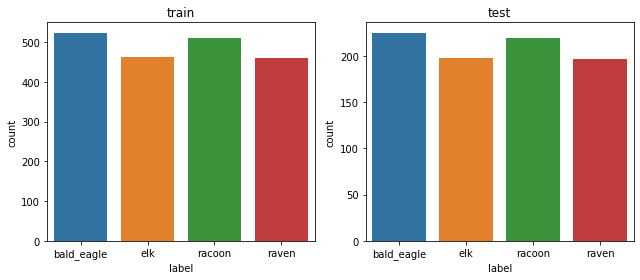

```python
plt.figure(figsize=(9,4))
plt.subplot(1,2,1)
sns.countplot(x="label", data=traindf), plt.title('train')
plt.subplot(1,2,2)
sns.countplot(x="label", data=testdf), plt.title('test')
plt.tight_layout()
plt.show()
```

```python
dataGen = preprocessing.image.ImageDataGenerator(rescale=1/255.0, validation_split=0.2)
```

```python
traindata = dataGen.flow_from_dataframe(
    dataframe=traindf,
    x_col = 'image',
    y_col = 'label',
    target_size = (100, 100),
    color_mode = 'grayscale',
    batch_size = 32,
    class_mode = 'categorical',
    shuffle = True,
    subset='training',
    validate_filenames=False
)
```

```
Found 1563 non-validated image filenames belonging to 4 classes.
```

```python
validationdata = dataGen.flow_from_dataframe(
    dataframe=traindf,
    x_col = 'image',
    y_col = 'label',
    target_size = (100, 100),
    color_mode = 'grayscale',
    batch_size = 32,
    class_mode = 'categorical',
    shuffle = False,
    subset='validation',
    validate_filenames=False
)
```

```
Found 390 non-validated image filenames belonging to 4 classes.
```

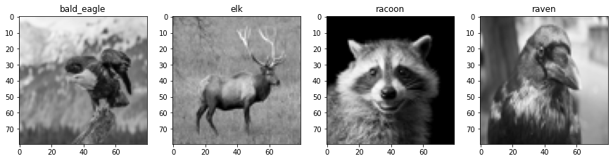

```python
plt.figure(figsize=(15,4))
for i in range(4):
    plt.subplot(1,4,i+1)
    img = Image.open(traindf[traindf['label']==classes[i]]['image'].iloc[0]).convert('LA')
    img = img.resize((80, 80))
    plt.imshow(img)
    plt.title(classes[i])
plt.show()
```

## Phase #2:

### Using RELU:

```python
input = layers.Input(shape=(100,100,1))
output = layers.Flatten()(input)
output = layers.Dense(1024, activation='relu')(output)
output = layers.Dense(512, activation='relu')(output)
output = layers.Dense(4, activation='softmax')(output)
```

```python
model = models.Model(inputs=input, outputs=output)
```

```python
model.compile(optimizer=optimizers.SGD(learning_rate=0.01), loss="categorical_crossentropy",metrics=['accuracy'])
```

```python
model.summary()
```

```
Model: "model"
_________________________________________________________________
 Layer (type)                Output Shape              Param #
=================================================================
 input_1 (InputLayer)        [(None, 100, 100, 1)]     0

 flatten (Flatten)           (None, 10000)             0

 dense (Dense)               (None, 1024)              10241024

 dense_1 (Dense)             (None, 512)               524800

 dense_2 (Dense)             (None, 4)                 2052

=================================================================
Total params: 10,767,876
Trainable params: 10,767,876
Non-trainable params: 0
_________________________________________________________________
```

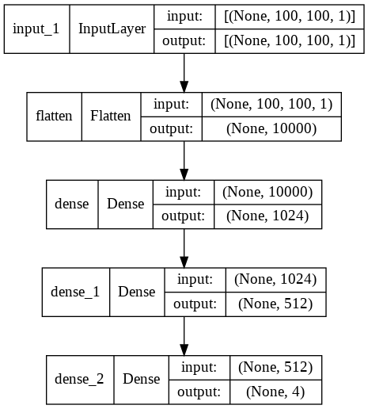

```python
utils.plot_model(model, show_shapes=True, expand_nested=True)
```

```python
log = model.fit(traindata, validation_data=validationdata, epochs=10)
```

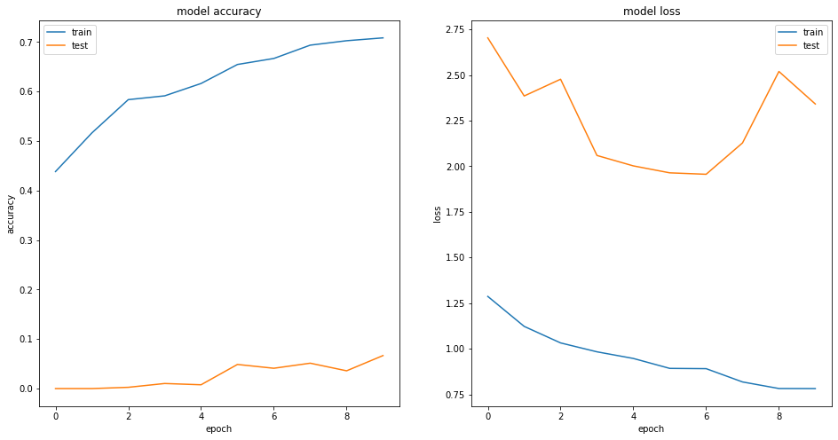

```python
plt.figure(figsize=(16,8))
plt.subplot(1,2,1)
plt.plot(log.history['accuracy'])
plt.plot(log.history['val_accuracy'])
plt.title('model accuracy')
plt.ylabel('accuracy')
plt.xlabel('epoch')
plt.legend(['train', 'test'])
plt.subplot(1,2,2)
plt.plot(log.history['loss'])
plt.plot(log.history['val_loss'])
plt.title('model loss')
plt.ylabel('loss')
plt.xlabel('epoch')
plt.legend(['train', 'test'])
plt.show()
```

```python
train = dataGen.flow_from_dataframe(
    dataframe=traindf,
    x_col = 'image',
    y_col = 'label',
    target_size = (100, 100),
    color_mode = 'grayscale',
    batch_size = 32,
    class_mode = 'categorical',
    shuffle = False,
    validate_filenames=False
)
test = dataGen.flow_from_dataframe(
    dataframe=testdf,
    x_col = 'image',
    y_col = 'label',
    target_size = (100, 100),
    color_mode = 'grayscale',
    batch_size = 32,
    class_mode = 'categorical',
    shuffle = False,
    validate_filenames=False
)
```

```
Found 1953 non-validated image filenames belonging to 4 classes.
Found 839 non-validated image filenames belonging to 4 classes.
```

```python
y_train = model.predict(train)
y_test = model.predict(test)
print("Train:")
print(classification_report(np.argmax(np.array(y_train), axis = 1), np.array(train.classes), target_names=classes))
print("Test:")
print(classification_report(np.argmax(np.array(y_test), axis = 1), np.array(test.classes), target_names=classes))
```

```
Train:
              precision    recall  f1-score   support

  bald_eagle       0.08      0.98      0.15        45
         elk       0.88      0.50      0.64       819
      racoon       0.48      0.79      0.59       305
       raven       0.90      0.52      0.66       784

    accuracy                           0.57      1953
   macro avg       0.58      0.70      0.51      1953
weighted avg       0.81      0.57      0.63      1953

Test:
              precision    recall  f1-score   support

  bald_eagle       0.04      0.80      0.07        10
         elk       0.82      0.45      0.58       364
      racoon       0.35      0.62      0.45       125
       raven       0.79      0.46      0.58       340

    accuracy                           0.48       839
   macro avg       0.50      0.58      0.42       839
weighted avg       0.73      0.48      0.55       839
```

### Using Leaky RELU:

```python
model = Sequential()
model.add(layers.Input(traindata.image_shape))
model.add(layers.Flatten())
model.add(layers.Dense(1024))
model.add(layers.LeakyReLU(alpha=0.05))
model.add(layers.Dense(512))
model.add(layers.LeakyReLU(alpha=0.05))
model.add(layers.Dense(4, activation='softmax'))
model.compile(optimizer=optimizers.SGD(learning_rate=0.01), loss="categorical_crossentropy",metrics=['accuracy'])
model.summary()
```

```
Model: "sequential_7"
_________________________________________________________________
 Layer (type)                Output Shape              Param #
=================================================================
 flatten_2 (Flatten)         (None, 10000)             0

 dense_25 (Dense)            (None, 1024)              10241024

 leaky_re_lu_12 (LeakyReLU)  (None, 1024)              0

 dense_26 (Dense)            (None, 512)               524800

 leaky_re_lu_13 (LeakyReLU)  (None, 512)               0

 dense_27 (Dense)            (None, 4)                 2052

=================================================================
Total params: 10,767,876
Trainable params: 10,767,876
Non-trainable params: 0
_________________________________________________________________
```

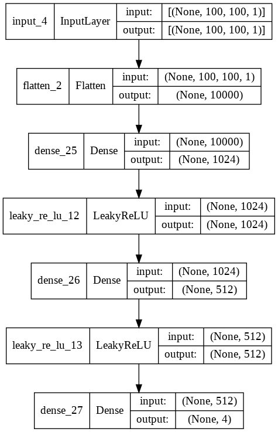

```python
utils.plot_model(model, show_shapes=True, expand_nested=True)
```

```python
log = model.fit(traindata, validation_data=validationdata, epochs=10)
```

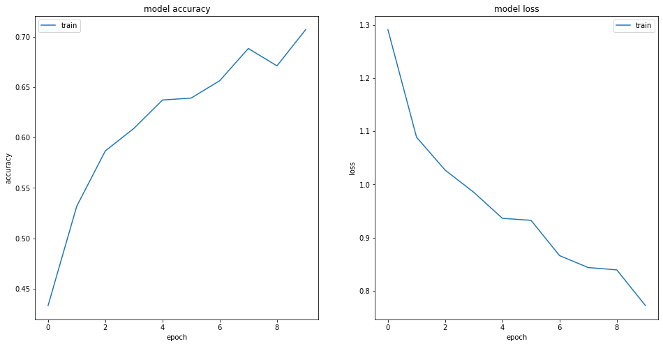

```python
plt.figure(figsize=(16,8))
plt.subplot(1,2,1)
plt.plot(log.history['accuracy'])
plt.title('model accuracy')
plt.ylabel('accuracy')
plt.xlabel('epoch')
plt.legend(['train'])
plt.subplot(1,2,2)
plt.plot(log.history['loss'])
plt.title('model loss')
plt.ylabel('loss')
plt.xlabel('epoch')
plt.legend(['train'])
plt.show()
```

```python
y_train = model.predict(train)
y_test = model.predict(test)
print("Train:")
print(classification_report(np.argmax(np.array(y_train), axis = 1), np.array(train.classes), target_names=classes))
print("Test:")
print(classification_report(np.argmax(np.array(y_test), axis = 1), np.array(test.classes), target_names=classes))
```

```
Train:
              precision    recall  f1-score   support

  bald_eagle       0.07      1.00      0.13        35
         elk       0.24      0.90      0.38       125
      racoon       0.75      0.61      0.68       627
       raven       0.96      0.38      0.54      1166

    accuracy                           0.50      1953
   macro avg       0.51      0.72      0.43      1953
weighted avg       0.83      0.50      0.57      1953

Test:
              precision    recall  f1-score   support

  bald_eagle       0.04      0.80      0.07        10
         elk       0.16      0.80      0.27        40
      racoon       0.67      0.51      0.58       286
       raven       0.91      0.36      0.51       503

    accuracy                           0.44       839
   macro avg       0.44      0.62      0.36       839
weighted avg       0.78      0.44      0.52       839
```

### Using Tanh:

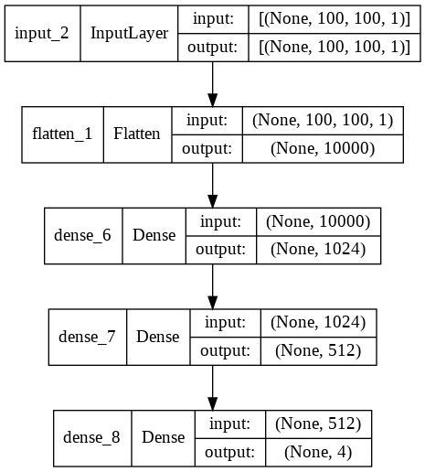

```python
input = layers.Input(shape=(100,100,1))
output = layers.Flatten()(input)
output = layers.Dense(1024, activation='tanh')(output)
output = layers.Dense(512, activation='tanh')(output)
output = layers.Dense(4, activation='softmax')(output)
model = models.Model(inputs=input, outputs=output)
model.compile(optimizer=optimizers.SGD(learning_rate=0.01), loss="categorical_crossentropy",metrics=['accuracy'])
utils.plot_model(model, show_shapes=True, expand_nested=True)
```

```python
log = model.fit(traindata, validation_data=validationdata, epochs=10)
```

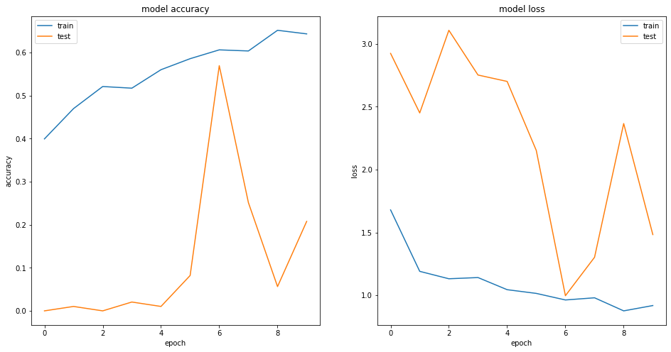

```python
plt.figure(figsize=(16,8))
plt.subplot(1,2,1)
plt.plot(log.history['accuracy'])
plt.plot(log.history['val_accuracy'])
plt.title('model accuracy')
plt.ylabel('accuracy')
plt.xlabel('epoch')
plt.legend(['train', 'test'])
plt.subplot(1,2,2)
plt.plot(log.history['loss'])
plt.plot(log.history['val_loss'])
plt.title('model loss')
plt.ylabel('loss')
plt.xlabel('epoch')
plt.legend(['train', 'test'])
plt.show()
```

```python
y_train = model.predict(train)
y_test = model.predict(test)
print("Train:")
print(classification_report(np.argmax(np.array(y_train), axis = 1), np.array(train.classes), target_names=classes))
print("Test:")
print(classification_report(np.argmax(np.array(y_test), axis = 1), np.array(test.classes), target_names=classes))
```

```
Train:
              precision    recall  f1-score   support

  bald_eagle       0.24      0.80      0.37       156
         elk       0.14      0.97      0.24        66
      racoon       0.97      0.37      0.53      1350
       raven       0.63      0.76      0.69       381

    accuracy                           0.50      1953
   macro avg       0.50      0.72      0.46      1953
weighted avg       0.82      0.50      0.54      1953

Test:
              precision    recall  f1-score   support

  bald_eagle       0.13      0.51      0.21        59
         elk       0.08      0.88      0.14        17
      racoon       0.94      0.34      0.50       610
       raven       0.49      0.63      0.55       153

    accuracy                           0.41       839
   macro avg       0.41      0.59      0.35       839
weighted avg       0.78      0.41      0.48       839
```

## Optimizers:

### Momentum:

Momentum is a widely-used strategy for accelerating the convergence of gradient-based optimization techniques.

Momentum is an average of gradients that changes during the time and we use it to update weight in each step. Therefore, it leads to faster convergence.

Normally, the updates to weights are **product** of `learning rate` and the `gradiant of error/loss`. But if we use momentum, we add a new term. For each new weight update, we add the product of momentum value and the previous update. **So the previous updates are considered on each.** Because of this one batch can't change the direction of descent if most of the previous batchs were moving toward a direction.

Using momentum the **learning will happen faster** as we will have bigger updates. It can also help us to **skip the local minima** because of the big update.

- A very large momentum can cause random behavior and prevent converging. Thus, it can stop the learning proccess. And a very small value won't help up much.

```python
model = models.Sequential()
model.add(layers.Input(shape=(100, 100, 1)))
model.add(layers.Flatten())
model.add(layers.Dense(1024, activation='relu'))
model.add(layers.Dense(1024, activation='relu'))
model.add(layers.Dense(4, activation='softmax'))

model.compile(
    loss='categorical_crossentropy',
    optimizer=optimizers.SGD(learning_rate=0.01, momentum=0.5),
    metrics=['accuracy', metrics.Precision()]
)
```

```python
model.summary()
```

```
Model: "sequential_8"
_________________________________________________________________
 Layer (type)                Output Shape              Param #
=================================================================
 flatten_3 (Flatten)         (None, 10000)             0

 dense_28 (Dense)            (None, 1024)              10241024

 dense_29 (Dense)            (None, 1024)              1049600

 dense_30 (Dense)            (None, 4)                 4100

=================================================================
Total params: 11,294,724
Trainable params: 11,294,724
Non-trainable params: 0
_________________________________________________________________
```

```python
log = model.fit(traindata, validation_data=validationdata, epochs=10)
```

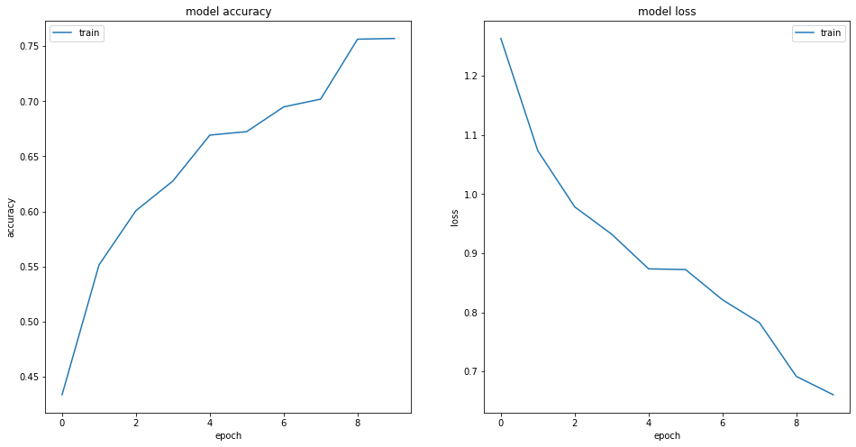

```python
plt.figure(figsize=(16,8))
plt.subplot(1,2,1)
plt.plot(log.history['accuracy'])
plt.title('model accuracy')
plt.ylabel('accuracy')
plt.xlabel('epoch')
plt.legend(['train'])
plt.subplot(1,2,2)
plt.plot(log.history['loss'])
plt.title('model loss')
plt.ylabel('loss')
plt.xlabel('epoch')
plt.legend(['train'])
plt.show()
```

```python
model = models.Sequential()
model.add(layers.Input(shape=(100, 100, 1)))
model.add(layers.Flatten())
model.add(layers.Dense(1024, activation='relu'))
model.add(layers.Dense(1024, activation='relu'))
model.add(layers.Dense(4, activation='softmax'))

model.compile(
    loss='categorical_crossentropy',
    optimizer=optimizers.SGD(learning_rate=0.01, momentum=0.9),
    metrics=['accuracy', metrics.Precision()]
)
model.summary()
```

```
Model: "sequential_9"
_________________________________________________________________
 Layer (type)                Output Shape              Param #
=================================================================
 flatten_4 (Flatten)         (None, 10000)             0

 dense_31 (Dense)            (None, 1024)              10241024

 dense_32 (Dense)            (None, 1024)              1049600

 dense_33 (Dense)            (None, 4)                 4100

=================================================================
Total params: 11,294,724
Trainable params: 11,294,724
Non-trainable params: 0
_________________________________________________________________
```

```python
log = model.fit(traindata, validation_data=validationdata, epochs=10)
```

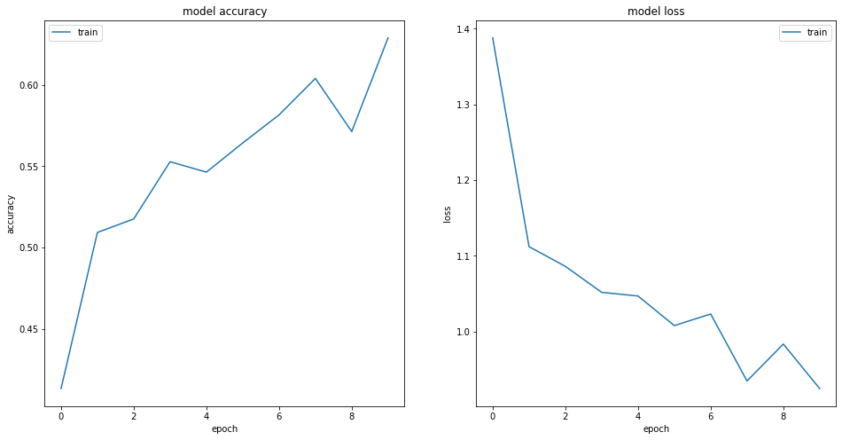

```python
plt.figure(figsize=(16,8))
plt.subplot(1,2,1)
plt.plot(log.history['accuracy'])
plt.title('model accuracy')
plt.ylabel('accuracy')
plt.xlabel('epoch')
plt.legend(['train'])
plt.subplot(1,2,2)
plt.plot(log.history['loss'])
plt.title('model loss')
plt.ylabel('loss')
plt.xlabel('epoch')
plt.legend(['train'])
plt.show()
```

### Adam:

```python
model = models.Sequential()
model.add(layers.Input(shape=(100, 100, 1)))
model.add(layers.Flatten())
model.add(layers.Dense(1024, activation='relu'))
model.add(layers.Dense(1024, activation='relu'))
model.add(layers.Dense(4, activation='softmax'))

model.compile(
    loss='categorical_crossentropy',
    optimizer='adam',
    metrics=['accuracy']
)
model.summary()
```

```
Model: "sequential_10"
_________________________________________________________________
 Layer (type)                Output Shape              Param #
=================================================================
 flatten_5 (Flatten)         (None, 10000)             0

 dense_34 (Dense)            (None, 1024)              10241024

 dense_35 (Dense)            (None, 1024)              1049600

 dense_36 (Dense)            (None, 4)                 4100

=================================================================
Total params: 11,294,724
Trainable params: 11,294,724
Non-trainable params: 0
_________________________________________________________________
```

```python
log = model.fit(traindata, validation_data=validationdata, epochs=10)
```

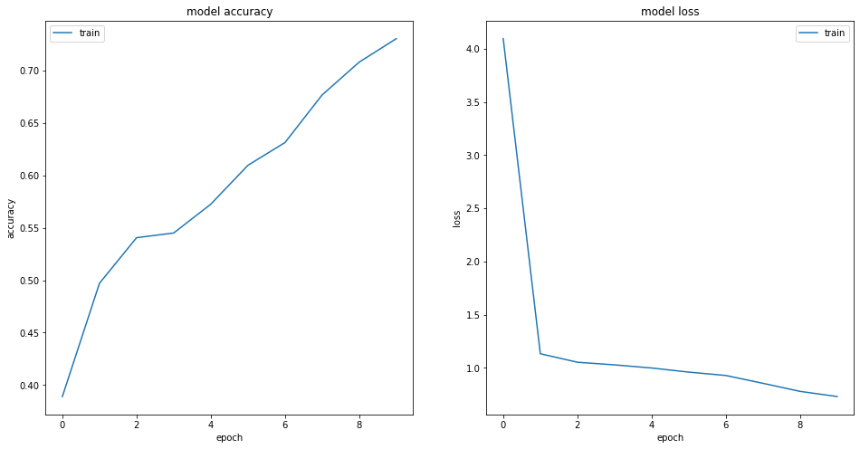

```python
plt.figure(figsize=(16,8))
plt.subplot(1,2,1)
plt.plot(log.history['accuracy'])
plt.title('model accuracy')
plt.ylabel('accuracy')
plt.xlabel('epoch')
plt.legend(['train'])
plt.subplot(1,2,2)
plt.plot(log.history['loss'])
plt.title('model loss')
plt.ylabel('loss')
plt.xlabel('epoch')
plt.legend(['train'])
plt.show()
```

## Epochs:

- the most common method for training in deep learning is a form of gradient descent. Each epoch finds the approximate direction that each parameter needs to be adjusted but it's just approximate. If you adjust too much in one epoch you will overshoot the set of parameters you're actually trying to find.
- We may not be able to have a lot of new data to train the model on, so we use the same data in multiple epochs to learn its features. But if we have enough data we may get the optimal result in one iteration.
- If we set the number of epochs to a very large number, it may lead to have and overfitted model, because we train the data for many times and our model will start to model the noises in our data and it is a sign of overfitting and the accuracy of the test data will be reduced.
- **Early stopping**: To prevent overfitting, we can use early-stopping techniques. It means we stop the learning process when the it evaluation data results start to worsening.

```python
model = models.Sequential()
model.add(layers.Input(shape=(100, 100, 1)))
model.add(layers.Flatten())
model.add(layers.Dense(1024, activation='relu'))
model.add(layers.Dense(512, activation='relu'))
model.add(layers.Dense(4, activation='softmax'))
model.compile(
    loss='categorical_crossentropy',
    optimizer='adam',
    metrics=['accuracy']
)
model.summary()
```

```
Model: "sequential_13"
_________________________________________________________________
 Layer (type)                Output Shape              Param #
=================================================================
 flatten_8 (Flatten)         (None, 10000)             0

 dense_43 (Dense)            (None, 1024)              10241024

 dense_44 (Dense)            (None, 512)               524800

 dense_45 (Dense)            (None, 4)                 2052

=================================================================
Total params: 10,767,876
Trainable params: 10,767,876
Non-trainable params: 0
_________________________________________________________________
```

```python
log = model.fit(traindata, validation_data=validationdata, epochs=20)
```

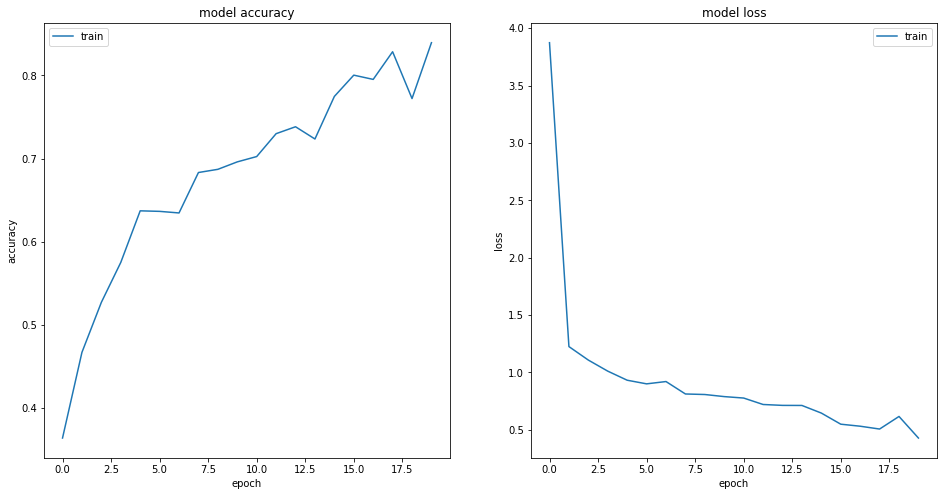

```python
plt.figure(figsize=(16,8))
plt.subplot(1,2,1)
plt.plot(log.history['accuracy'])
plt.title('model accuracy')
plt.ylabel('accuracy')
plt.xlabel('epoch')
plt.legend(['train'])
plt.subplot(1,2,2)
plt.plot(log.history['loss'])
plt.title('model loss')
plt.ylabel('loss')
plt.xlabel('epoch')
plt.legend(['train'])
plt.show()
```

```python
y_train = model.predict(train)
y_test = model.predict(test)
print("Train:")
print(classification_report(np.argmax(np.array(y_train), axis = 1), np.array(train.classes), target_names=classes))
print("Test:")
print(classification_report(np.argmax(np.array(y_test), axis = 1), np.array(test.classes), target_names=classes))
```

```
Train:
              precision    recall  f1-score   support

  bald_eagle       0.36      0.92      0.52       205
         elk       0.99      0.67      0.80       680
      racoon       0.96      0.80      0.88       610
       raven       0.80      0.81      0.80       458

    accuracy                           0.77      1953
   macro avg       0.78      0.80      0.75      1953
weighted avg       0.87      0.77      0.80      1953

Test:
              precision    recall  f1-score   support

  bald_eagle       0.20      0.70      0.31        64
         elk       0.89      0.55      0.68       319
      racoon       0.81      0.67      0.73       266
       raven       0.66      0.68      0.67       190

    accuracy                           0.63       839
   macro avg       0.64      0.65      0.60       839
weighted avg       0.76      0.63      0.67       839
```

## Loss Function:

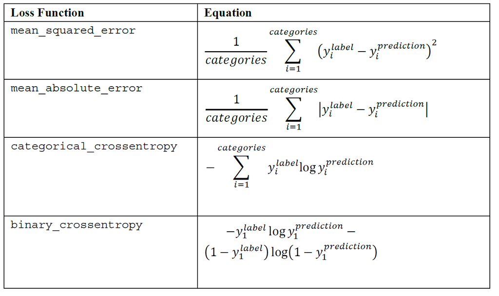

- *Cross-entropy* is prefered for **classification**, while *mean squared error*(MSE) is one of the best choices for **regression**. This comes directly from the statement of the problems itself - in classification you work with very particular set of possible output values thus MSE is badly defined (as it does not have this kind of knowledge thus penalizes errors in incompatible way).

```python
model = models.Sequential()
model.add(layers.Input(shape=(100, 100, 1)))
model.add(layers.Flatten())
model.add(layers.Dense(1024, activation='relu'))
model.add(layers.Dense(512, activation='relu'))
model.add(layers.Dense(4, activation='softmax'))
model.compile(
    loss='mean_squared_error',
    optimizer='adam',
    metrics=['accuracy']
)
model.summary()
```

```
Model: "sequential_16"
_________________________________________________________________
 Layer (type)                Output Shape              Param #
=================================================================
 flatten_11 (Flatten)        (None, 10000)             0

 dense_52 (Dense)            (None, 1024)              10241024

 dense_53 (Dense)            (None, 512)               524800

 dense_54 (Dense)            (None, 4)                 2052

=================================================================
Total params: 10,767,876
Trainable params: 10,767,876
Non-trainable params: 0
_________________________________________________________________
```

```python
log = model.fit(traindata, validation_data=validationdata, epochs=10)
```

## Regularization:

A neural network has the tendency to memorize its training. In such cases, the network fails catastrophically when subjected to the test data. This is the classic case of the network failing to generalize.

- Using L2 method, in each update to weight, we add a product of constant and the previous weight. This constant is predefined and independent of the learning process, so this change to weight, keeps the model from overfitting.

```python
model = models.Sequential()
model.add(layers.Input(shape=(100, 100, 1)))
model.add(layers.Flatten())
model.add(layers.Dense(1024, activation='relu', kernel_regularizer=regularizers.l2(l2=0.0001)))
model.add(layers.Dense(512, activation='relu', kernel_regularizer=regularizers.l2(l2=0.0001)))
model.add(layers.Dense(4, activation='softmax'))
model.compile(
    loss='categorical_crossentropy',
    optimizer='Adam',
    metrics=['accuracy']
)
model.summary()
```

```
Model: "sequential_19"
_________________________________________________________________
 Layer (type)                Output Shape              Param #
=================================================================
 flatten_14 (Flatten)        (None, 10000)             0

 dense_58 (Dense)            (None, 1024)              10241024

 dense_59 (Dense)            (None, 512)               524800

 dense_60 (Dense)            (None, 4)                 2052

=================================================================
Total params: 10,767,876
Trainable params: 10,767,876
Non-trainable params: 0
_________________________________________________________________
```

```python
log = model.fit(traindata, validation_data=validationdata, epochs=18)
```

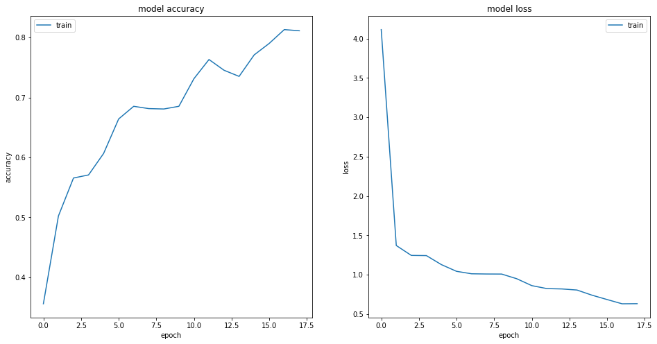

```python
plt.figure(figsize=(16,8))
plt.subplot(1,2,1)
plt.plot(log.history['accuracy'])
plt.title('model accuracy')
plt.ylabel('accuracy')
plt.xlabel('epoch')
plt.legend(['train'])
plt.subplot(1,2,2)
plt.plot(log.history['loss'])
plt.title('model loss')
plt.ylabel('loss')
plt.xlabel('epoch')
plt.legend(['train'])
plt.show()
```

```python
y_train = model.predict(train)
y_test = model.predict(test)
print("Train:")
print(classification_report(np.argmax(np.array(y_train), axis = 1), np.array(train.classes), target_names=classes))
print("Test:")
print(classification_report(np.argmax(np.array(y_test), axis = 1), np.array(test.classes), target_names=classes))
```

```
Train:
              precision    recall  f1-score   support

  bald_eagle       0.42      0.80      0.55       273
         elk       0.95      0.72      0.82       605
      racoon       0.82      0.93      0.87       447
       raven       0.94      0.68      0.79       628

    accuracy                           0.77      1953
   macro avg       0.78      0.78      0.76      1953
weighted avg       0.84      0.77      0.78      1953

Test:
              precision    recall  f1-score   support

  bald_eagle       0.28      0.54      0.37       118
         elk       0.81      0.56      0.66       286
      racoon       0.53      0.75      0.62       153
       raven       0.82      0.57      0.68       282

    accuracy                           0.60       839
   macro avg       0.61      0.61      0.58       839
weighted avg       0.69      0.60      0.62       839
```

## Dropout:

- The idea of dropout is simple. Given a dropout rate, the Dropout layer randomly removes that fraction of units from participating in the next layer. The Dropout layer makes neural networks robust to unforeseen input data because the network is trained to predict correctly, even if some units are missing. It's worth noting that dropout is not used in the output layer and it is only active during training. Moreover, dropout is not present during predictions.

```python
model = models.Sequential()
model.add(layers.Input(shape=(100, 100, 1)))
model.add(layers.Flatten())
model.add(layers.Dense(1024, activation='relu'))
model.add(layers.Dropout(0.1))
model.add(layers.Dense(512, activation='relu'))
model.add(layers.Dropout(0.1))
model.add(layers.Dense(4, activation='softmax'))
model.compile(
    loss='categorical_crossentropy',
    optimizer='Adam',
    metrics=['accuracy']
)
model.summary()
```

```
Model: "sequential_21"
_________________________________________________________________
 Layer (type)                Output Shape              Param #
=================================================================
 flatten_16 (Flatten)        (None, 10000)             0

 dense_62 (Dense)            (None, 1024)              10241024

 dropout (Dropout)           (None, 1024)              0

 dense_63 (Dense)            (None, 512)               524800

 dropout_1 (Dropout)         (None, 512)               0

 dense_64 (Dense)            (None, 4)                 2052

=================================================================
Total params: 10,767,876
Trainable params: 10,767,876
Non-trainable params: 0
_________________________________________________________________
```

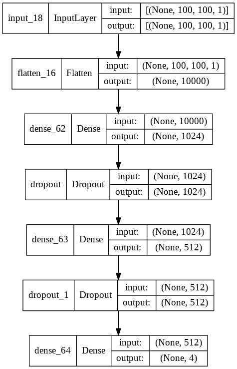

```python
utils.plot_model(model, show_shapes=True, expand_nested=True)
```

```python
log = model.fit(traindata, validation_data=validationdata, epochs=18)
```

```python
y_test = model.predict(test)
y_test = np.argmax(np.array(y_test), axis = 1)
y_true = np.array(test.classes)
print(classification_report(y_test, y_true, target_names=classes))
```

```
              precision    recall  f1-score   support

  bald_eagle       0.01      1.00      0.02         2
         elk       0.52      0.60      0.55       171
      racoon       0.66      0.47      0.55       308
       raven       0.86      0.47      0.61       358

    accuracy                           0.50       839
   macro avg       0.51      0.64      0.43       839
weighted avg       0.72      0.50      0.58       839
```

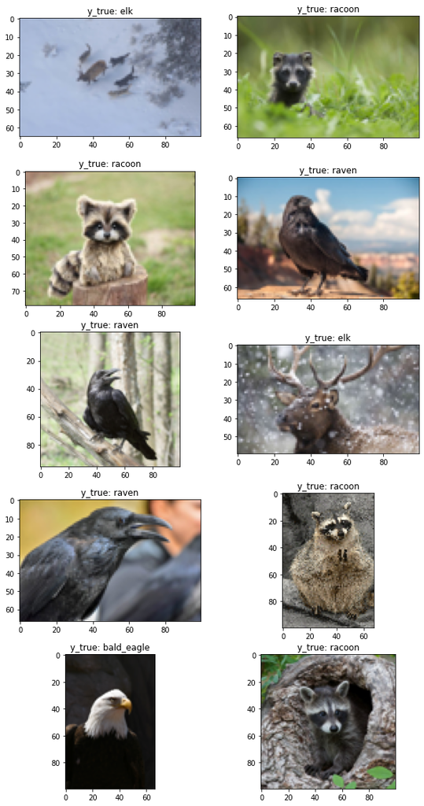

```python
cnt = 0
plt.figure(figsize=(10,20))
for i in np.random.randint(0, len(test.classes), 40):
  if(y_test[i] == y_true[i]):
    plt.subplot(5,2,cnt+1)
    img = Image.open(test.filenames[i])
    img.thumbnail((100, 100))
    plt.imshow(img)
    plt.title('y_true: ' + cmap[y_true[i]])
    cnt += 1
    if cnt == 10:
        break
```

```python
cmap = {v:k for k,v in test.class_indices.items()}
cmap
```

```
{0: 'bald_eagle', 1: 'elk', 2: 'racoon', 3: 'raven'}
```

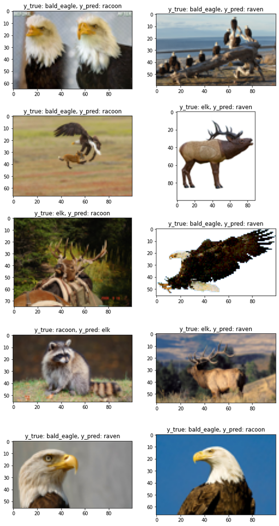

```python
cnt = 0
plt.figure(figsize=(10,20))
for i in np.random.randint(0, len(test.classes), 30):
  if(y_test[i] != y_true[i]):
    plt.subplot(5,2,cnt+1)
    img = Image.open(test.filenames[i])
    img.thumbnail((100, 100))
    plt.imshow(img)
    plt.title('y_true: ' + cmap[y_true[i]] + ', y_pred: ' + cmap[y_test[i]])
    cnt += 1
    if cnt == 10:
        break
```